# TALLLER DERIVADAS

Juan Anagrita, HectorHernandez, Aldemar Ramirez

October 27,2019

## Problema a y b

1. Teniendo en cuenta lo anterior, genere una tabla para evaluar el valor aproximado𝑓′(𝑥) = 𝑥𝑐𝑜𝑥de 𝒇´(𝟏. 𝟖) ≈ para los siguientes valores de ℎ =0.1,0.01,0.0011,0.0001.
2. Estime el valor aproximado de las cotas del error para el problema anterior

## Solución

```r
f = function(x){
  return (x*cos(x))
}

print(f(pi))
```

```
## [1] -3.141593
```

```r
aproximacionDerivada = function(x0,h){
  result = (f(x0+h)-f(x0))/h
}

hs = c(0.1,0.01,0.001,0.0001,0.00001)

f1=expression(x*cos(x))

fp = D(f1,'x')

g = function(x){eval(fp)}
print(g(1.8))
```

```
## [1] -1.980128
```

```r
resultados = c()
error = c()
real = c()
for(i in hs){
resultados = c(resultados,aproximacionDerivada(1.8,i))
  real = c(real,g(1.8))
}

error = resultados - real

tablaResultados <- data.frame(
  "h" = hs,
  "Derivada aprox" = resultados,
  "valor real" = real,
  "error" = error
)

print(tablaResultados)
```

```
##       h Derivada.aprox valor.real         error
## 1 1e-01      -2.052864  -1.980128 -7.273624e-02
## 2 1e-02      -1.987781  -1.980128 -7.652937e-03
## 3 1e-03      -1.980897  -1.980128 -7.689598e-04
## 4 1e-04      -1.980205  -1.980128 -7.693252e-05
## 5 1e-05      -1.980136  -1.980128 -7.693625e-06
```

## Problema D

4. Supóngase que se tienen tres puntos dados por 𝑥0; 𝑥1 = 𝑥0 + ℎ; 𝑥2 = 𝑥0 + 2ℎ Encuentre la formula conocida de tres puntos para determinar una aproximaciónde 𝑓′(𝑥0) Donde, 𝜉0se encuentra entre 𝑥0 y 𝑥0 + 2ℎ. Utilice está fórmula paraencontrar ≈ 𝑓´(1.8)

## Solucion D

la formula a usar va a ser la siguiente:
$$f´(x_0)= 1/(2h)*[-3f(x_0)+4f(x_0+h)-f(x_0+2h)] + h^2/3 * f^{(3)}(E_0)$$

```r
aproximacionDerivada2 = function(x0,h){
  result =  1/(2*h)*(-3*f(x0)+4*f(x0+h)-f(x0+2*h))
}

res1 = aproximacionDerivada2(1.8,0.00001)

cat("f'(1.8) = ",res1, "\n")
```

```
## f'(1.8) =  -1.980128
```

```r
cat("Error Absoluto = ",abs(res1-real[1]), "\n")
```

```
## Error Absoluto =  1.099769e-10
```

```r
cat("Error relativo = ",abs(res1-real[1])/real[1] *100, "\n")
```

```
## Error relativo =  -5.554031e-09
```

## Problema E

5. Realice una modificación de la fórmula de los tres puntos, tomando valores entre (𝑥0 − ℎ) y (𝑥0 + ℎ) y compare la magnitud del error con la fórmula de la parte e

## Solucion E

La formula que se va a usar es la siguiente:
$$f´(x_0)= 1/(2h)*[-f(x_0-h)+f(x_0+h)]-h^2/6* f^{(3)}(E_0)$$

```r
aproximacionDerivada3 = function(x0,h){
  result = 1/(2*h)*(-f(x0-h)+f(x0+h))
}

res2 = aproximacionDerivada3(1.8,0.00001)

cat("f'(1.8) = ",res2, "\n")
```

```
## f'(1.8) =  -1.980128
```

```r
cat("Error Absoluto = ",abs(res2-real[1]), "\n")
```

```
## Error Absoluto =  2.60254e-11
```

```r
cat("Error relativo = ",abs(res2-real[1])/real[1] *100, "\n")
```

```
## Error relativo =  -1.314329e-09
```

```r
cat("Diferencia error punto e vs d = ",abs((res1-real[1]) - (res2-real[1])), "\n")
```

```
## Diferencia error punto e vs d =  1.360023e-10
```

## Problema F

6. Utilice la fórmula para cinco puntos alrededor de 𝑥0 y aplíquela y compárela con todas las formulas anteriores

## Solucion F

La formula que se va a usar es la siguiente: $f´(x_0)= [f(x_0-2h)-8f(x_0-h)+8f(x_0+h)-f(x_0+2h)]/(12h) + h^4/30* f^{(5)}(E_0)$

```r
aproximacionDerivada4 = function(x0,h){
  result = (f(x0-2*h)-8*f(x0-h)+8*f(x0+h)-f(x0+2*h))/(12*h)
}

res3 = aproximacionDerivada4(1.8,0.00001)

cat("f'(1.8) = ",res3, "\n")
```

```
## f'(1.8) =  -1.980128
```

```r
cat("Error Absoluto = ",res3-real[1], "\n")
```

```
## Error Absoluto =  -2.254685e-11
```

```r
cat("Error relativo = ",abs(res3-real[1])/real[1] *100, "\n")
```

```
## Error relativo =  -1.138656e-09
```

```r
cat("Diferencia Error punto f v.s d = ",abs((res1-real[1]) - (res3-real[1])), "\n")
```

```
## Diferencia Error punto f v.s d =  8.743006e-11
```

```r
cat("Diferencia Error punto f v.s e = ",abs((res2-real[1]) - (res3-real[1])), "\n")
```

```
## Diferencia Error punto f v.s e =  4.857226e-11
```

```r
print(abs(res2-real[1])>abs(res3-real[1]))
```

```
## [1] TRUE
```

## Problema G

7. Aplique la fórmula adecuada para aproximar 𝑓 (1.8) justifique su respuesta

## Solucion G

La formula mas adecuada para aproximar la derivada es la de los 5 puntos siendo las que tiene una mayor presicion.

```r
aproximacionDerivada4 = function(x0,h){
  result = (f(x0-2*h)-8*f(x0-h)+8*f(x0+h)-f(x0+2*h))/(12*h)
}

res3 = aproximacionDerivada4(1.8,0.00001)

cat("f'(1.8) = ",res3, "\n")
```

```
## f'(1.8) =  -1.980128
```

```r
cat("Error Absoluto = ",res3-real[1], "\n")
```

```
## Error Absoluto =  -2.254685e-11
```

```r
cat("Error relativo = ",abs(res3-real[1])/real[1] *100, "\n")
```

```
## Error relativo =  -1.138656e-09
```

## Problema H

8. Teniendo en cuenta que el error total (ℎ)= error de redondeo + error de truncamiento dado por: $e(h) = E/h+h^2/6M$ una función del tamaño del paso. Encuentre el tamaño óptimo del paso

## Solucion H

```r
  f2=expression(E/h + (h^2)/6 * M)

  f2p = D(f2,'h')

  g2 = function(x){eval(f2p)}
```

como se puede ver la funcion del error total al derivarse para hallar el valor oprimo queda dada por
$$e'(h)=(h/3)*M-E/(h^2)$$

para hallar el valor optimo de h se iguala la derivada a 0

$$0=(h/3)*M-E/(h^2)$$

y se despeja h

$$h=(3*E/M)^{(1/3)}$$

## Problema I

1. El siguiente código está dado para la aproximar 𝑓′(1); f(x) = xe^x, realice una gráfica que muestre como varia la precisión en función de ℎ

## Solucion I

```r
library(pracma)
f=function(x) x*exp(x)
r=5.436563656918091
h=0.1

errores = c()
valH = c()

for (i in 1:15){
 d=(f(1+h)-f(1))/h
 e=abs(r-d)
 errores = c(errores,e)
 valH = c(valH,h)
cat(formatC(c(h, r, d, e), width = -20, format = "f", flag = " ",digits
= 15),"\n")
 h=h/10
}
```

```
##  0.100000000000000    5.436563656918091    5.863007978820320    0.426444321902229
##  0.010000000000000    5.436563656918091    5.477519670804032    0.040956013885941
##  0.001000000000000    5.436563656918091    5.440642892414527    0.004079235496436
##  0.000100000000000    5.436563656918091    5.436971417318581    0.000407760400490
##  0.000010000000000    5.436563656918091    5.436604431396929    0.000040774478838
##  0.000001000000000    5.436563656918091    5.436567733774210    0.000004076856119
##  0.000000100000000    5.436563656918091    5.436564070038229    0.000000413120138
##  0.000000010000000    5.436563656918091    5.436563643712588    0.000000013205503
##  0.000000001000000    5.436563656918091    5.436564087801797    0.000000430883706
##  0.000000000100000    5.436563656918091    5.436566752337056    0.000003095418965
##  0.000000000010000    5.436563656918091    5.436584515905450    0.000020858987359
##  0.000000000001000    5.436563656918091    5.437428285404166    0.000864628486075
##  0.000000000000100    5.436563656918091    5.435651928564766    0.000911728353326
##  0.000000000000010    5.436563656918091    5.417888360170763    0.018675296747328
##  0.000000000000001    5.436563656918091    6.217248937900876    0.780685280982785
```

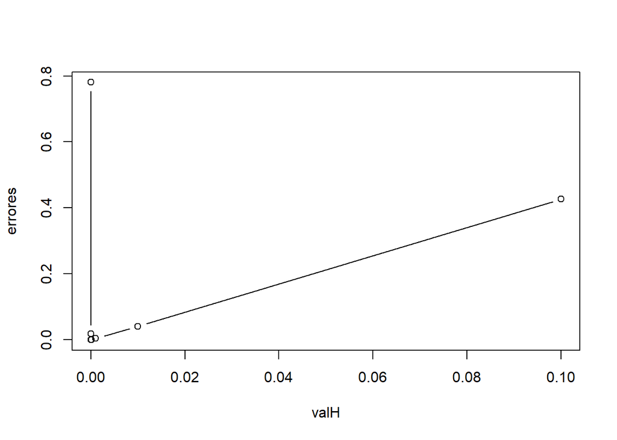

```r
plot(valH,errores, type = "b")
```

## Problema H

t = 1.00,1.01,1.02,1.03,1.04 i = 3.10,3.12,3.14,3.18,3.24

## Solucion H

sea h = 0.01

```r
h = 0.01
R = 0.142
L = 0.098
i = c(3.1,3.12,3.14,3.18,3.24)

E = function(L,R,h,i){
  d = (-i[1]+8*i[2]-8*i[4]+i[5])/(12*h)
  r = L*d+R*i[3]
  return(r)
}

result = E(L,R,h,i)

cat("Para t = 1.02 el voltaje vale ",result, "\n")
```

```
## Para t = 1.02 el voltaje vale  0.1682133
```